# 第七讲：模拟退火方法

模拟退火法(Simulation Annealing)是希伯来大学的Scott Kirkpatrick教授在1983年的一个论文[1]中正式提出的。事实上，Cerny也独立地发表了相关的工作[2]。

### 模拟退火过程

本质上是一个Metropolis算法。模拟退火法的基本思想，源自于统计力学（Statistical mechanics）：

- 一个热系统可通过退火过程达到内部能量最小的状态

假设优化问题的能量函数为$f(x)$,其状态概率服从玻尔兹曼分布，即概率密度是 $$ \frac{1}{Z}e^{-\frac{f(x)}{k_B T}}, $$ 其中，$Z$是归一化因子（配分函数）。考虑用随机的方式产生一个建议状态y。

[figure not shown]

### 状态转移机制

模拟退火法的核心步骤是实现状态的转移：从当前x到新状态y的接受概率由下式给出： $$ h(x,y) = \min \Big\{ 1, e^{-\frac{f(y) - f(x)}{k_B T}} \Big\}.$$ 由上式可知，推过的过程实质上是导入了一种状态转移机制。为了让状态转移收敛得更快，不断降低$T$的数值是一个传统的做法，往往是可以达到收敛的。

由Metropolis算法的机制可以知道，让退火过程的状态序列称为Markov链的两个条件为：

- 不可约性：对于$\Omega$中任意两个不同的状态$x$和$y$，只需经过有限次转移总能从$x$到达$y$
- 对称性：转移概率$g$满足$g(x | y) = g(y | x), \forall x,y$

## 例1： 求Shekel函数极值

已知Shekel函数 $$ f(x) = \sum_{i=1}^{m}\frac{1}{a_i(x - b_i)^2 + c_i},$$ 其中，$a_i,b_i,c_i$为常数且要求$a_i>0,c_i>0,i=1,\cdots,m$。一般地，函数中的$m$不宜超过$30$。当$a_i>0,c_i>0$时，该函数均有$f(x)>0,\quad\forall x\in\mathbb{R}$，且它的各个峰值分别位于点$b_i,i=1,2,\ldots,m$，并且$a_i$是相应的衰变率。

求：Shekel函数的极小值点?

```matlab
graphics_toolkit('gnuplot')   % 在Octave的GUI界面或者MATLAB界面下不需要设置此项 %gnuplot
```

```matlab
%% octave/matlab function
shekel = @(x) 1 ./(10.295*(x-7.382).^2 + 0.1613) + 1 ./(4.722*(x-1.972).^2+0.2327);
```

[output not shown]

```matlab
min_x = 2; max_x = 9;
xx = min_x:0.01:max_x;
yy = shekel(xx);
```

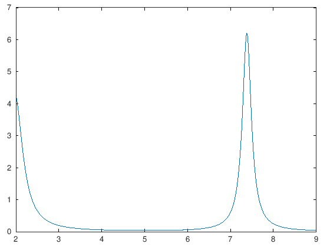

```matlab
plot(xx, yy);
```

冷却进度表用于降低算法中的虚拟温度，其目的是使系统运行在平衡态，并使算法在有效时间内逼近最优解。这就是模拟退火算法的关键之处，人们把$T$的选择历史记录为“冷却进度表”，是收到了淬火物理过程的启发。一般采用如下的“退火”步骤：

- 设置开始冷却的初始温度$T_0$，通常可以取$100$至$2000$
- 给出温度$T$的衰减函数，确定每次冷却下降多少温度。衰减的速率要小，常常采用的形式有：
  - 几何冷却方式 $$ T_{k+1} = \alpha T_{k}, k = 0,1,2,\ldots, $$ 其中，常数$0<\alpha<1$, $\alpha$控制着降温的速率，其数值越大，降温速率越小。这里取值范围往往为$[0.5 ~ 0.99]$
  - 逆对数的冷却方式 $$ F = \frac{c}{a + ln t},$$ 其中， $a$和$c$是常数，这里$c$通常是一个很大的正数。
- 在每一温度$T$下需要迭代的次数，即在等温过程下控制合适的Markov链长度$L_k$，如果温度下降足够慢，可省略该步骤
- 给定冷却的终止温度$T_f$，达到冷却的停止点。注意停止温度$T_f$应设为足够小，经验上为$[0.01,5]$的范围内

```matlab
# try it in MATLAB
```

```matlab
[x, fval, exitFlag, output] = simulannealbnd(@shekel, 2.1, 2, 9);
```

[output not shown]

[output not shown]

[figure not shown]

```matlab
plot(xx, yy); hold on; plot(x,shekel(x), 'r*'); hold off;
```

### 收敛性

[哈耶克定理] 在不可约及对称转移条件下，如果温度衰减被取为迭代$t$的函数： $$ T_t = \frac{c}{ln(1+t)}, \quad t=1,2,\cdots, $$ 其中,$c$是足够大的常数。则当$t\rightarrow\infty$时，模拟退火产生的马尔可夫链$X_t$将以概率$1$趋于全局最小解，即 $$ \lim_{t\rightarrow\infty} P(X_t\in G)=1$$

## 例2. 旅行商问题(Travel Salesman Problem)

```matlab
cityXY = [ 66.83 61.95 40 24.39 17.07 22.93 51.71 87.32 68.78 84.88 50 40 25; ...
         25.36 26.34 44.39 14.63 22.93 76.1 94.14 65.36 52.19 36.09 30 20 26];
initialTemp = 1;
coolRate = 0.99;
nSwap = 3;
maxIter = 2000;
```

由于图形较复杂，让我们用一个M脚本来绘制城市路径的顺序

```matlab
function plot_city(cityXY)
    % 这个函数画城市的位置与旅行路径图
    pos_1 = plot(cityXY(1,:), cityXY(2,:), 'b*');
    % set(pos_1, 'erasemode', 'none');
    set(pos_1, 'color', 'r')
    % hold on;
    pos_2 = line(cityXY(1,:),cityXY(2,:), 'Marker', '*');
    set(pos_2, 'color' ,'r');
    x = [cityXY(1,1), cityXY(1,length(cityXY))];
    y = [cityXY(2,1), cityXY(2,length(cityXY))];
    x1 = 10*round(max(cityXY(1,:))/10);
    y1 = 10*round(max(cityXY(2,:))/10);
    if x1 == 0
        x1 = 1;
    end
    if y1 == 0
        y1 = 1;
    end
    axis([0 x1 0 y1])
    pos_3 =line(x,y);
    set(pos_3, 'color', 'r');
    dist = distance(cityXY);
    dist_print = sprintf('%d-city travel distance = %4.6f', length(cityXY), dist);
    text(x1/15, 1.05*y1, dist_print, 'fontweight', 'bold');
end
```

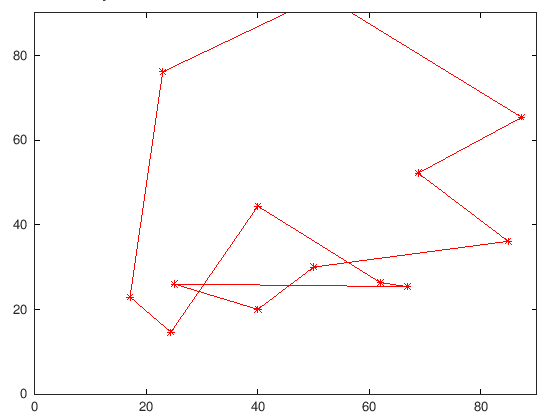

```matlab
plot_city(cityXY)
```

给定$n$个城市，其地理坐标表示为$C_i,i=1,2,\cdots,n$,旅行开始城市是$C_1$,然后按照路径从一个城市到下一个城市，最后回到$C_1$,每个城市恰好去游玩一次。线路表示为$x=(i_1,i_2,..,i_n−1)$是${2，3，…,n}$的置换，其中$i_0=1$。$\Omega$是所有旅行线路的全体。则旅行线路长度为路径的长度为 $$ E(x) = \sum_{k=1}^{n-1} d(C_{i_{k-1}},C_{i_k}) + d(C_{i_{n-1}},C_{i_0}), $$ 其中，$d(C_i,C_j)$表示城市$C_i$到城市$C_j$的距离。求：最短路径及其长度是多少？

### 部分路径逆转法

```matlab
function s = swapcities(cityXY, m)
    s = cityXY;
    for i = 1 : m
        city_1 = round(length(s)*rand(1));
        if city_1 < 1
        	city_1 = 1;
        end
        city_2 = round(length(s)*rand(1));
        if city_2 < 1
        	city_2 = 1
        end
        temp = s(:, city_1);
        s(:,city_1) = s(:,city_2);
        s(:,city_2) = temp;
    end
end
```

本质上，上述过程是一个随机模拟过程，依赖于随机被选中进行逆转的顺序。这一过程不断重复执行，可能造成的结果也会由于交换顺序的不同而不同。那么，这样的过程是否总能收敛到一个确定的状态呢？让我们先通过一段这样的脚本进行多次尝试。

```matlab
function d = distance(cityXY)
% 这个函数计算路径的总长度
d =0;
for n = 1 : length(cityXY)
   if n == length(cityXY)
        d = d + norm(cityXY(:,n) - cityXY(:,1));
   else
        d = d + norm(cityXY(:,n) - cityXY(:,n+1));
   end
end
end
```

```matlab
function [iter, temp] = TSPSA(cityXY, initialTemp, coolRate, maxIter, nSwap)
    temp = initialTemp;
    iter = 1;
    final_temp_iterations = 0;
    while iter < maxIter
        previous_distance = distance(cityXY);
        pos_cities = swapcities(cityXY, nSwap);
        current_distance = distance(pos_cities);
        diff = abs(current_distance - previous_distance);
        if current_distance < previous_distance
            cityXY = pos_cities;
            plot_city(cityXY);
            if final_temp_iterations >= 10
                temp = coolRate*temp;
                final_temp_iterations = 0;
            end
            nSwap = round(nSwap*exp(-diff/(iter*temp)));
            if nSwap == 0
                nSwap = 1;
            end
            iter = iter + 1;
            final_temp_iterations = final_temp_iterations
        else
            if rand(1) < exp(-diff/temp)
                cityXY = pos_cities;
                plot_city(cityXY);
                nSwap = round(nSwap * exp(-diff/(iter*temp)));
                if nSwap == 0
                    nSwap = 1;
                end
                final_temp_iterations = final_temp_iterations + 1;
                iter = iter + 1;
            end
        end
    end
end
```

[output not shown]

[output not shown]

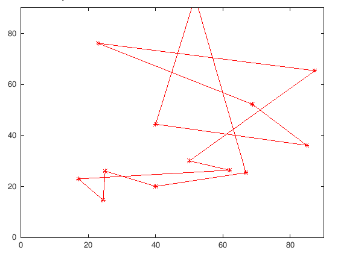

```matlab
[iterations, temperature] = TSPSA(cityXY, initialTemp, coolRate, maxIter, nSwap);
```

```matlab
fprintf('Number of  iterations = %d.\n', iterations);
fprintf('The final temperature = %3.8f.\n', temperature);
```

[output not shown]

#### 路径逆转的另一个版本

上述实现中的部分路径逆转是完全随机的，通过模拟可见其效率较低，并不能让人满意。如果把部分路径逆转的随机选取城市节点有效性提高，则可以进一步考虑Metropolis抽样：

Initial: 产生{2,3,…,n}的一个随机置换x并计算能量E(x) T←T(0),B←E(x),t←0 Loop until T=T_f y←被部分逆转的x的路径 计算E(y) ∆E←E(y)−E(x) ℎ←min{1,e^−ΔE/T} 产生均匀分布的随机数r~U(0,1) if r<ℎ then x←y E(x)←E(y) end if B←min{B,E(x)} t←t+1 T←T(t) End loop

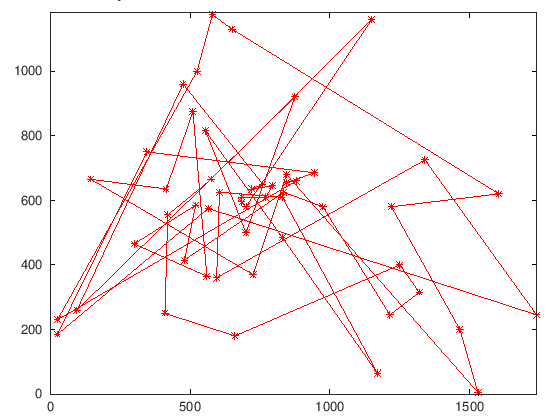

```matlab
%Coord = csvread('code/TSP/city.csv');  % copy from city.csv
Coord = [565.0,575.0;25.0,185.0;345.0,750.0;945.0,685.0;845.0,655.0; ...
         880.0,660.0;25.0,230.0;525.0,1000.0;580.0,1175.0;650.0,1130.0;...
         1605.0,620.0;1220.0,580.0;1465.0,200.0;1530.0,  5.0;845.0,680.0;...
         725.0,370.0;145.0,665.0;415.0,635.0;510.0,875.0;560.0,365.0;...
         300.0,465.0;520.0,585.0;480.0,415.0;835.0,625.0;975.0,580.0;...
         1215.0,245.0;1320.0,315.0;1250.0,400.0;660.0,180.0;410.0,250.0;...
         420.0,555.0;575.0,665.0;1150.0,1160.0;700.0,580.0;685.0,595.0;...
         685.0,610.0;770.0,610.0;795.0,645.0;720.0,635.0;760.0,650.0;...
         475.0,960.0;95.0,260.0;875.0,920.0;700.0,500.0;555.0,815.0;...
         830.0,485.0;1170.0, 65.0;830.0,610.0;605.0,625.0;595.0,360.0;...
         1340.0,725.0;1740.0,245.0]';
initialTemp = 5000;   coolRate = 0.95;       nSwap = 3;     maxIter = 2000;
plot_city(Coord);
```

[output not shown]

[output not shown]

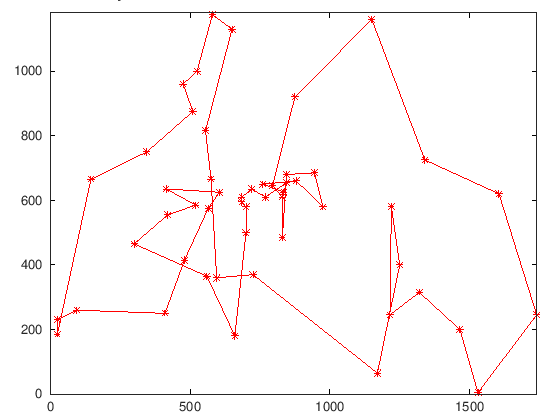

```matlab
[iterations, temperature] = TSPSA(Coord, initialTemp, coolRate, maxIter, nSwap)
```

```matlab
% 其他案例
%cityXY = rand(2, 31);
%x = TSPSA(cityXY, 100, 0.5, 4000, 20);

%cityXY = rand(2, 51);
%x = TSPSA(cityXY, 100, 0.5, 4000, 20);

%cityXY = rand(2, 71);
%x = TSPSA(cityXY, 100, 0.5, 4000, 20);

%cityXY = rand(2, 101);
%x = TSPSA(cityXY, 100, 0.5, 4000, 20);

%cityXY = rand(2, 101);
%x = TSPSA(cityXY, 100, 0.5, 4000, 40);

% x = TSPSA(cityXY, 800, 0.95, 10000, 500);
```

## 例3：背包问题(Back Packing)

[figure not shown]

背包问题：给定一组物品，每种物品都有自己的重量和价格，在限定的总重量内，我们如何选择，才能使得物品的总价格最高。 假设有$n$种物品，物品$j$的重量为$w_j$,价值为$p_j$，假设所有物品的重量和价格都是非负的，背包能承受的最大重量为W。如果限定每种物品只能选择$0$个或$1$个，则问题称为$0$-$1$背包问题。可以用公式表示为： $$ \max_{x_1,x_2,\ldots,x_n} \sum_{j=1}^{n}p_j x_j, \qquad s.t. \sum_{j=1}^{n}\omega_j x_j \le W, \quad x_j \in \{0,1\},$$ 其中，$x_j$表示物品$j$的取舍，$0$表示舍弃，$1$表示录取。

背包问题的求解是一个典型的组合数学问题，问题可以描述为寻找一个一维数组$(x_1,x_2,\cdots,x_n)$的最优值。寻找的过程类似于TSP问题，可以采用部分路径你转发，每次随机逆转某个$x_j$的取值。当然，逆转的做法可以有很多种，下面展示一种方案：

```matlab
while iterations < maxIter
    %产生随机扰动
    tmp = ceil(rand*num);
    sol_new(1,tmp) = ~sol_new(1,tmp);
    %检查是否满足约束
    while 1
        q = (sol_new * W <= restriction);
        if ~q
           %如果不满足约束随机丢弃一个物品
            temp2=find(sol_new==1);
            temp3=ceil(rand*length(temp2));
            sol_new(temp2(temp3))=~sol_new(temp2(temp3));
        else
            break
        end
    end
end
```

这里展示其完整的实现函数

```matlab
% load code/backpack_sa.m
```

```matlab
function backpack_sa(P,W,restriction,initialTemp, endTemp,coolRate, maxIter, nSwap)
% P 价格
% W 重量
% restriction 重量限制
num = nSwap;
P = -P;
sol_new = ones(1,num);          %生成初始解
E_current = inf;
E_best = inf;
%E_current是当前解对应的目标函数值（即背包中物品总价值）
%E_new是新解的目标函数值
%E_best是最优解
sol_current = sol_new;
sol_best = sol_new;
t = initialTemp;
tf = endTemp;
iterations = 1;

while t>tf
    while iterations < maxIter
        %产生随机扰动
        tmp = ceil(rand*num);
        sol_new(1,tmp) = ~sol_new(1,tmp);
        %检查是否满足约束
        while 1
            q = (sol_new * W <= restriction);
            if ~q
               %如果不满足约束随机放弃一个物品
                temp2=find(sol_new==1);
                temp3=ceil(rand*length(temp2));
                sol_new(temp2(temp3))=~sol_new(temp2(temp3));
            else
                break
            end
        end

        %计算背包中的物品价值
        E_new = sol_new * P;
        if E_new < E_current
            E_current = E_new;
            sol_current = sol_new;
            if E_new < E_best
                E_best = E_new;
                sol_best = sol_new;
            end
            iterations = iterations + 1;
        else
            if rand < exp( -(E_new - E_current) / t)
                E_current = E_new;
                sol_current = sol_new;
                iterations = iterations + 1;
            else
                sol_new = sol_current;
            end
        end
        t = t * coolRate;
    fprintf('迭代次数 = %d', iterations);
    disp('当前解为:');
    disp(sol_best)
    disp('物品总价值等于:');
    val = -E_best;
    disp(val);
    disp('背包中物品重量是:');
    disp(sol_best * W);
    end
end
end
```

```matlab
P = [5;10;13;4;3;11;13;10;8;16;7;4];    %价值
W = [2;5;18;3;2;5;10;4;11;7;14;6];      %重量
restriction = 44;   % 重量限制
initialTemp = 97;
coolRate = 0.95;
endTemp = 3;
maxIter = 1000;
nSwap = 12;
```

```matlab
backpack_sa(P,W,restriction,initialTemp, endTemp,coolRate, maxIter, nSwap);
```

[output not shown]

### 例4：顶点着色问题

给定一个无向图 G = (V, E) ，其中V为顶点集合，E为边集合，图着色问题即为将V分为K个颜色组，每个组形成一个独立集，即其中没有相邻的顶点。目标是求得最小的K值。如下图所示为地图着色应用案例

[figure not shown]

模拟退火求解顶点着色问题，类似部分逆转法，每次都随机的将图中的某种颜色替换掉。其核心代码也是类似于路径交换

```matlab
while 1
        sol_new(ceil(rand*num)) =
                 sol_current(ceil(rand*num));
        if detect(graph, X, Y, sol_new)
            break
        else
            sol_new = sol_current;
        end
 end
```

### 研究历史

- 1983, Kirkpatrick S. etc., Optimization by simulated annealing，Science, 220 (1983), 671-680.
- 1984, German S. & German D. 给出退火率与退火时间的对数成反比的版本(题名 Equation of state calculation by Fast Computing Machines)
- 1985, Cerny V.运用SA求解Traveling Salesman Problem(TSP)
- 1986, Szu H.，提出一种退火率与时间成反比的Fast Simulated Annealing(FSA)
- 1987, Corana A. 求解多目标连续变量优化问题；
- 1987，Laarhoven P. & Aarts E.出版《模拟退火的理论和应用》
- 1989, Charnes A. & Wolfe M. : 收敛性研究；Aarts E.结合SA和ANN分析Boltzmann机
- 1990, Gunte D. & Tobias S.研究SA中初始温度临界值的确定方法
- 1992, Laarhoven P. 运用SA解决(NP完全) Jobshop问题; Ingber L.等人提出Very Fast SA
- 1993, Kirkpatrick S. 运用SA到一般优化问题
- 1995, Tarek M. 等人提出并行模拟退火算法，更适用于解决复杂的开学和工程问题
- 1997, Ali & Storey 研究连续变量优化问题，提出Aspiration based Simulated Annealing(ASA)以及 Direct search Simulated Annealing(DSA)
- 2001,都志辉等人提出混合SPMD模拟退火算法，取得Scalable并行结果。

### 基于退火原理的量子计算机

D-Wave自1999年成立以来，一直专注于退火量子技术，其量子退火系统更是出售给了一些重量级客户，其中包括军火巨头洛克希德马丁、IT巨头谷歌、美国宇航局、洛斯阿拉莫斯国家实验室等。到2020年为止，D-Wave是5000量子比特计算平台Advantage是唯一商用量子退火机(quantum annealing machine)。IBM 过去曾发表过一篇学术论文认为 D-Wave 的量子退火系统不是真正的量子计算机[3]。D-Wave 也表示，其退火量子计算系统是专为优化而设计，但却不能在模拟量子系统方面发挥作用。2021年10月05日宣布：将开始构建门型量子计算机，并预计将于2023 年或 2024 年将60-Qubit的量子系统推向市场。将采用超导材料为其通用量子计算机构建量子比特。这与IBM、谷歌、初创公司 Rigetti Computing、本源量子等公司采用的方法相同。

- [1] S. Kirkpatrick, C. Gelatt, M. Vecchi: Optimization by simulated annealing，Science, 220 (1983), pp. 671-680.
- [2] Cerny, Thermodynamical approach to the traveling salesman problem: an efficient simulation algorithm, Journal of Optimization Theory and Applications, 45 (1985), pp. 41-51.
- [3] https://arxiv.org/pdf/1401.7087v1.pdf

## 上机练习

参考讲稿课后作业(2,3,6)